# Cover Letter - Shritheja Undar

Shritheja Undar

May 14, 2018

#### ————————————–

#### Dear Hiring Manager,

Please consider my resume for the position of Digital Marketing Internship posted at the Lab 916 career portal. Lab 916, with its focus on product innovation and commitment towards improving customer experience, rightly aligns with my passion. I believe my experience in data analytics, market research and product management, makes me an exceptional candidate.

I am first year MBA /MS in Business Analytics dual degree candidate at the University of Notre Dame - Mendoza College of Business and hold a bachelor’s degree in Mechanical engineering. I am a successful management professional with 5 years of experience; leading cross-functional teams, developing niche products and handling complex data analysis.

Some of my most relevant experiences include:

#### Data analytics and market research:

I have significant experience with quantitative research tools and data analytics packages such as R, SPSS, SAS, SQL and Tableau. I have piloted many technical analyses on aircraft flight data and cohort analysis on customer data. I have led primary market research, user requirement assortment and cost time estimation for new generation drones.

I have also initiated the market entry research for a transport network company startup and was instrumental in strategizing their initial digital marketing campaigns. The digital media marketing campaign was focused on retargeting the customers and promotion of new services.

#### Product development and Project management

Developed niche technology products such as simulation systems for aircrafts and analysis packages for helicopter. I have also led cross functional teams to conduct the feasibility study of drones, price negotiating teams for analysis tool procurement and engineering teams to build low-cost drones for visual data processing. I have 5 years of product handling experience and have supervised the projects from concept to completion.

#### Operations and Customer support

Led a team of experienced technicians to devise solutions to issues encountered at various customer based on data analytics. Further, implemented the auto snag rectification modules and data handling system for smooth interaction between customer bases and product development teams

In closing, I believe I would be a great fit for the team and would perfectly align with Lab 916’s goals and culture. My accomplishments and qualifications are further detailed in the attached resume. I would welcome the opportunity to discuss with you in detail about the role and my credentials.

Sincerely,

Shritheja Undar

## ———————————————-

## ———————————————-

# Sample Amazon Review Analysis

I have done a sample Amazon review analysis using R and published it as HTML file.

Data Source: https://www.kaggle.com/datafiniti/consumer-reviews-of-amazon-products.

The program processes the reviews and highlights the most used words as well as computes the average rating for top manufacturers

#### Extracting the title

```r
CleanedPro_C <- Corpus (VectorSource(AData$reviews.title))
```

#### Cleaning the text

```r
toSpace <- content_transformer(function (x , pattern ) gsub(pattern, " ", x))
CleanedPro_C <- tm_map(CleanedPro_C, toSpace, "/")
CleanedPro_C <- tm_map(CleanedPro_C, toSpace, "@")
CleanedPro_C <- tm_map(CleanedPro_C, toSpace, "\\|")
CleanedPro_C <- tm_map(CleanedPro_C, removeNumbers)
```

#### Processing the words

```r
dtm <- TermDocumentMatrix(CleanedPro_C)
m <- as.matrix(dtm)
v <- sort(rowSums(m),decreasing=TRUE)
d <- data.frame(word = names(v),freq_pro=v)
```

#### Amazon Reviews WordCloud

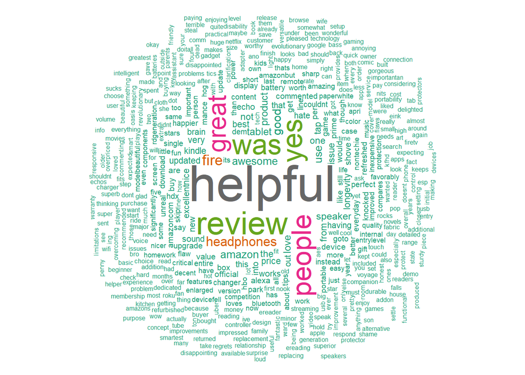

```r
wordcloud(words = d$word, freq = d$freq_pro, min.freq = 1,
          max.words=500, random.order=FALSE, rot.per=0.35,
          colors=brewer.pal(8, "Dark2"))
```

#### Top Amazon Manufacturer from Reviews Ratings

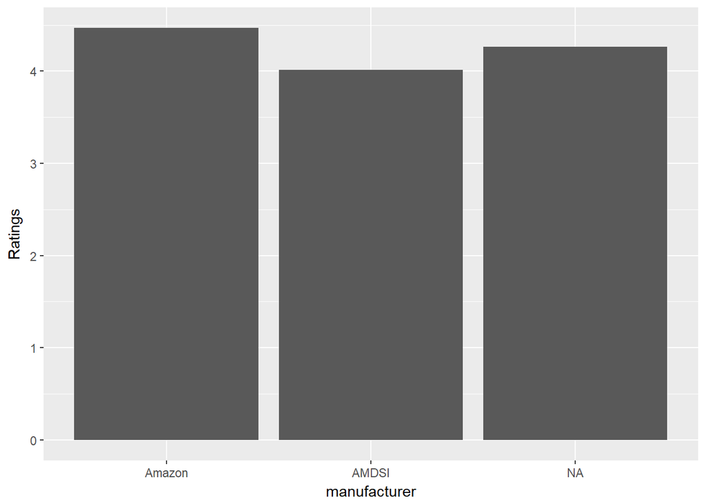

```r
AData1 %>%
  group_by(manufacturer)%>%
  summarise(Ratings = mean(reviews.rating, na.rm = TRUE))%>%
  ggplot(mapping = aes(x=manufacturer, y = Ratings))+
  geom_col()
```

### I would really appreciate if I could get an opportunity to present myself